# Session 4: Homework 2

```python
# Import libraries

import pandas as pd
import pandas_datareader.data as web
import seaborn as sns
import numpy as np
from scipy import stats                # library for using advanced mathematical formulas & statistical techniques
import yfinance as yf
import seaborn as sns
import matplotlib.pyplot as plt
import matplotlib.ticker as mticker
import matplotlib.dates as mdates
from datetime import datetime, date
from skimpy import skim
import warnings
warnings.filterwarnings('ignore')


# Set style for better looking plots
# plt.style.use('seaborn-v0_8')
# sns.set_palette("husl")
```

# Climate change and temperature anomalies

If we wanted to study climate change, we can find data on the *Combined Land-Surface Air and Sea-Surface Water Temperature Anomalies* in the Northern Hemisphere at [NASA's Goddard Institute for Space Studies](https://data.giss.nasa.gov/gistemp). The [tabular data of temperature anomalies can be found here](https://data.giss.nasa.gov/gistemp/tabledata_v4/NH.Ts+dSST.txt)

To define temperature anomalies you need to have a reference, or base, period which NASA clearly states that it is the period between 1951-1980.

```python
# Load weather data
weather = pd.read_csv("https://data.giss.nasa.gov/gistemp/tabledata_v4/NH.Ts+dSST.csv",
                      skiprows=1,
                      na_values="***")


# Data Inspection
print("Weather data info:")
print(weather.info()) # viewing different variables, their data types etc.
print("nFirst few rows:")
print(weather.head()) # Viewing the first 5 rows of the dataset
```

```
Weather data info:
<class 'pandas.core.frame.DataFrame'>
RangeIndex: 147 entries, 0 to 146
Data columns (total 19 columns):
 #   Column  Non-Null Count  Dtype
---  ------  --------------  -----
 0   Year    147 non-null    int64
 1   Jan     147 non-null    float64
 2   Feb     147 non-null    float64
 3   Mar     147 non-null    float64
 4   Apr     147 non-null    float64
 5   May     147 non-null    float64
 6   Jun     147 non-null    float64
 7   Jul     147 non-null    float64
 8   Aug     146 non-null    float64
 9   Sep     146 non-null    float64
 10  Oct     146 non-null    float64
 11  Nov     146 non-null    float64
 12  Dec     146 non-null    float64
 13  J-D     146 non-null    float64
 14  D-N     145 non-null    float64
 15  DJF     146 non-null    float64
 16  MAM     147 non-null    float64
 17  JJA     146 non-null    float64
 18  SON     146 non-null    float64
dtypes: float64(18), int64(1)
memory usage: 21.9 KB
None
nFirst few rows:
   Year   Jan   Feb   Mar   Apr   May   Jun   Jul   Aug   Sep   Oct   Nov  \
0  1880 -0.37 -0.52 -0.24 -0.30 -0.07 -0.17 -0.20 -0.27 -0.24 -0.32 -0.43
1  1881 -0.31 -0.23 -0.04  0.00  0.03 -0.34  0.07 -0.05 -0.27 -0.44 -0.37
2  1882  0.25  0.21  0.02 -0.30 -0.23 -0.29 -0.28 -0.17 -0.26 -0.52 -0.34
3  1883 -0.58 -0.65 -0.15 -0.29 -0.24 -0.11 -0.06 -0.23 -0.34 -0.15 -0.44
4  1884 -0.16 -0.10 -0.63 -0.58 -0.35 -0.41 -0.40 -0.51 -0.45 -0.44 -0.58

    Dec   J-D   D-N   DJF   MAM   JJA   SON
0 -0.41 -0.30   NaN   NaN -0.20 -0.21 -0.33
1 -0.24 -0.18 -0.20 -0.32 -0.01 -0.11 -0.36
2 -0.69 -0.22 -0.18  0.07 -0.17 -0.24 -0.37
3 -0.15 -0.28 -0.33 -0.64 -0.23 -0.13 -0.31
4 -0.47 -0.42 -0.40 -0.14 -0.52 -0.44 -0.49
```

You have two objectives in this section:

1. Select the year and the twelve month variables from the `weather` dataset. We do not need the others (J-D, D-N, DJF, etc.) for this assignment.
2. Convert the dataframe from wide to 'long' format. Name the new dataframe as `tidyweather`, name the variable containing the name of the month as `month`, and the temperature deviation values as `delta`.

```python
# List the 12 month column names in calendar order.
month_cols = ['Jan','Feb','Mar','Apr','May','Jun',
              'Jul','Aug','Sep','Oct','Nov','Dec']

# Build a tidy ("long") version of the NASA temperature data.
# Each row will be one year-month observation.
tidyweather = (
    weather
    # Keep only the year and the monthly anomaly columns.
    .loc[:, ['Year'] + month_cols]
    # Convert from wide to long: one row per year-month.
    .melt(id_vars='Year', var_name='month', value_name='delta')
)

# Preview the result.
print(tidyweather.head())
```

```
   Year month  delta
0  1880   Jan  -0.37
1  1881   Jan  -0.31
2  1882   Jan   0.25
3  1883   Jan  -0.58
4  1884   Jan  -0.16
```

## Plotting Information

Let us plot the data using a time-series scatter plot, and add a trendline. To do that, we first need to create a new variable called `date` in order to ensure that the `delta` values are plot chronologically.

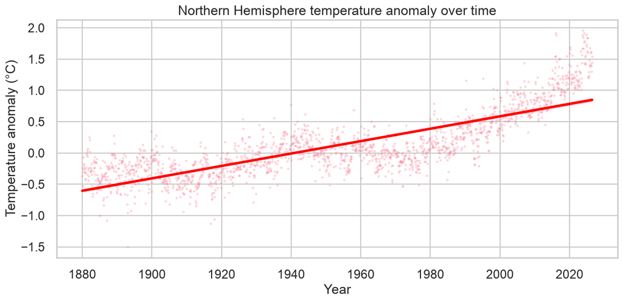

```python
# Prepare the data: drop missing values and create a numeric date for the trend line.
plot_data = (
    tidyweather
    # Remove missing temperature readings so the regression line works cleanly.
    .dropna(subset=['delta'])
    .assign(
        # Build a real datetime from Year and month (e.g., "1880-Jan-01").
        date=lambda d: pd.to_datetime(d['Year'].astype(str) + '-' + d['month'] + '-01'),
        # matplotlib needs a numeric x-axis to fit the regression line.
        date_num=lambda d: mdates.date2num(d['date'])
    )
)

# Create the plot: scatter of anomalies over time with a fitted trend line.
plt.figure(figsize=(12, 6))
sns.regplot(data=plot_data, x='date_num', y='delta',
            scatter_kws={'alpha': 0.3, 's': 10},
            line_kws={'color': 'red'})

# Format the numeric x-axis back into readable years.
plt.gca().xaxis.set_major_formatter(mdates.DateFormatter('%Y'))
plt.gca().xaxis.set_major_locator(mdates.YearLocator(20))

plt.title('Northern Hemisphere temperature anomaly over time')
plt.xlabel('Year')
plt.ylabel('Temperature anomaly (°C)')
plt.tight_layout()
plt.show()
```

Is the effect of increasing temperature more pronounced in some months? Use faceting to produce a separate scatter plot for each month, again with a smoothing line.

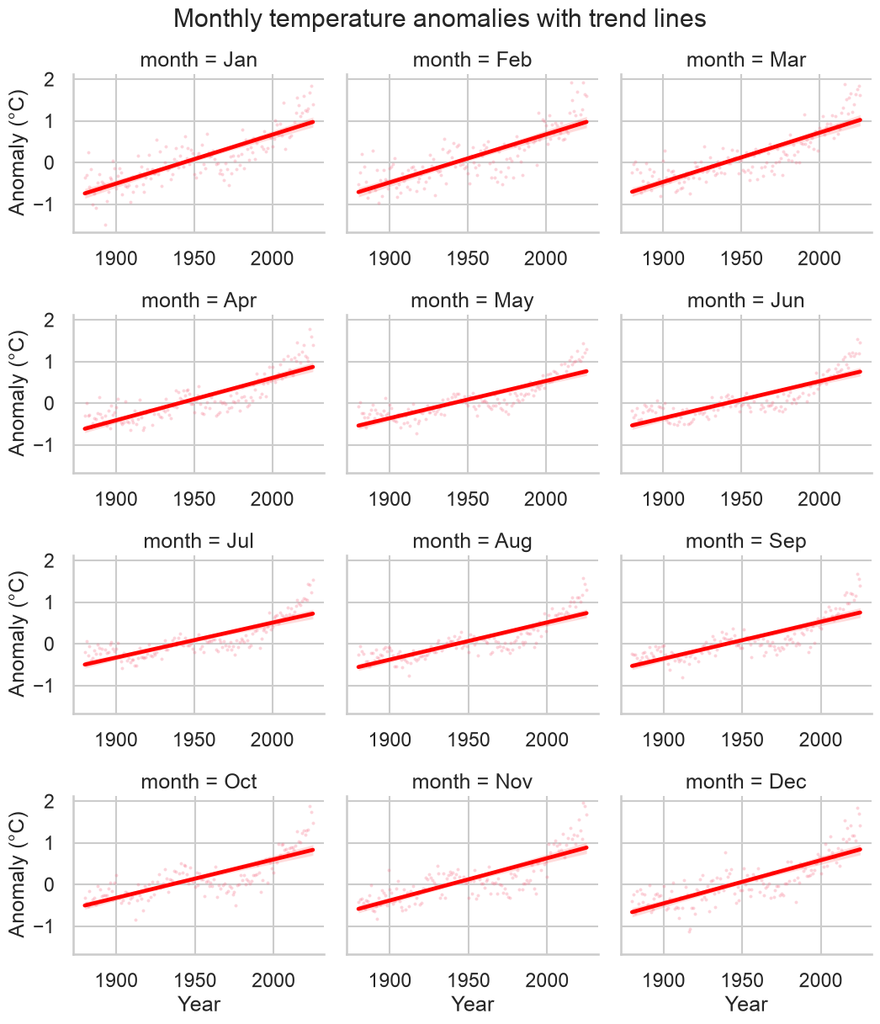

```python
# Put the months in calendar order so the facets are laid out sensibly.
month_order = ['Jan','Feb','Mar','Apr','May','Jun',
               'Jul','Aug','Sep','Oct','Nov','Dec']

# Prepare data and enforce month ordering.
plot_data = (
    tidyweather
    .dropna(subset=['delta'])
    .assign(month=lambda d: pd.Categorical(d['month'], categories=month_order, ordered=True))
)

# One subplot per month, each with its own regression line.
g = sns.FacetGrid(plot_data, col='month', col_wrap=3,
                  height=3, aspect=1.2, sharex=False, sharey=True)
g.map_dataframe(sns.regplot, x='Year', y='delta',
                scatter_kws={'alpha': 0.3, 's': 8},
                line_kws={'color': 'red'})
g.set_axis_labels('Year', 'Anomaly (°C)')
g.fig.suptitle('Monthly temperature anomalies with trend lines', y=1.02)
plt.show()
```

It is sometimes useful to group data into different time periods to study historical data. For example, we often refer to decades such as 1970s, 1980s, 1990s etc. to refer to a period of time. NASA calculates a temperature anomaly, as difference from the base period of 1951-1980.

```python
# Define the year bins and human-readable labels.
interval_bins = [1880, 1920, 1950, 1980, 2010, 2030]
interval_labels = ['1881-1920', '1921-1950', '1951-1980', '1981-2010', '2011-present']

# Add an interval column using pd.cut, which assigns each year to a bucket.
comparison = (
    tidyweather
    .dropna(subset=['delta'])
    .query('Year >= 1881')
    .assign(
        interval=lambda d: pd.cut(
            d['Year'], bins=interval_bins, labels=interval_labels, right=True
        )
    )
)

print(comparison.head())
```

```
   Year month  delta   interval
1  1881   Jan  -0.31  1881-1920
2  1882   Jan   0.25  1881-1920
3  1883   Jan  -0.58  1881-1920
4  1884   Jan  -0.16  1881-1920
5  1885   Jan  -1.00  1881-1920
```

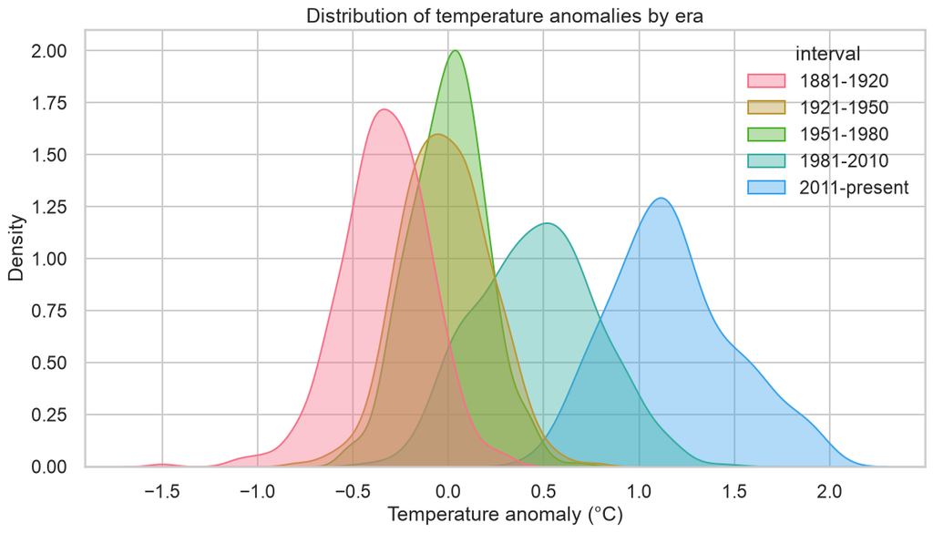

```python
# Compare the distributions of anomalies across historical eras.
plt.figure(figsize=(12, 7))
sns.kdeplot(data=comparison, x='delta', hue='interval',
            fill=True, common_norm=False, alpha=0.4)
plt.title('Distribution of temperature anomalies by era')
plt.xlabel('Temperature anomaly (°C)')
plt.ylabel('Density')
plt.tight_layout()
plt.show()
```

So far, we have been working with monthly anomalies. However, we might be interested in average annual anomalies. We can do this by using `group_by()` and `mean()`, followed by a scatter plot to display the result.

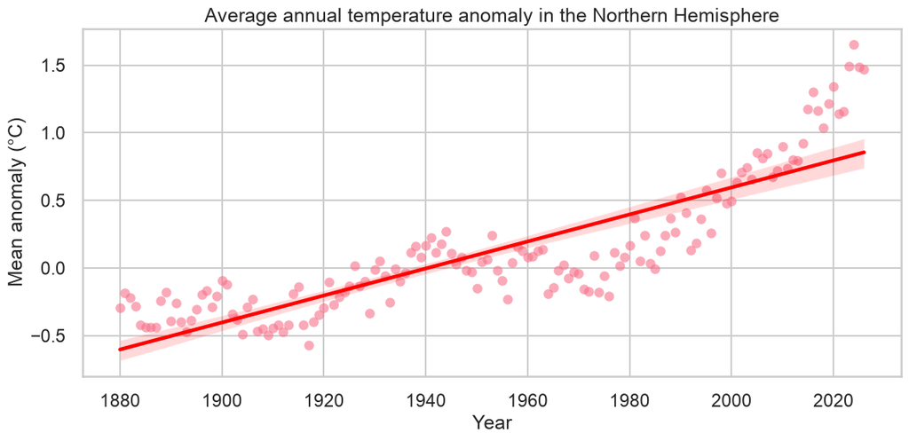

```python
# Compute the average anomaly for each year.
annual = (
    tidyweather
    .dropna(subset=['delta'])
    .groupby('Year', as_index=False)
    .agg(mean_delta=('delta', 'mean'))
)

# Plot year against the annual mean, with a trend line.
plt.figure(figsize=(12, 6))
sns.regplot(data=annual, x='Year', y='mean_delta',
            scatter_kws={'alpha': 0.6}, line_kws={'color': 'red'})
plt.title('Average annual temperature anomaly in the Northern Hemisphere')
plt.xlabel('Year')
plt.ylabel('Mean anomaly (°C)')
plt.tight_layout()
plt.show()
```

## Confidence Interval for `delta`

[NASA points out on their website](https://earthobservatory.nasa.gov/world-of-change/decadaltemp.php) that

> A one-degree global change is significant because it takes a vast amount of heat to warm all the oceans, atmosphere, and land by that much. In the past, a one- to two-degree drop was all it took to plunge the Earth into the Little Ice Age.

Your task is to construct a confidence interval for the average annual delta since 2011, both using a formula and using a bootstrap simulation.

```python
# Use the annual means from 2011 onward.
recent_annual = annual.query('Year >= 2011')['mean_delta']

# Sample statistics needed for the t-based confidence interval.
n = len(recent_annual)                       # number of annual observations
mean_delta = recent_annual.mean()            # sample mean
sd_delta = recent_annual.std(ddof=1)         # sample standard deviation
se_delta = sd_delta / np.sqrt(n)             # standard error of the mean
t_crit = stats.t.ppf(0.975, df=n-1)          # critical value for 95% CI

# Lower and upper bounds.
ci_lower = mean_delta - t_crit * se_delta
ci_upper = mean_delta + t_crit * se_delta

print(f'Mean annual delta (2011-present): {mean_delta:.3f}°C')
print(f'95% CI via formula: [{ci_lower:.3f}, {ci_upper:.3f}]°C')
```

```
Mean annual delta (2011-present): 1.180°C
95% CI via formula: [1.035, 1.326]°C
```

```python
# Number of bootstrap resamples.
n_boot = 10_000

# Resample the recent annual means with replacement many times,
# then take the mean of each resampled sample.
rng = np.random.default_rng(42)
boot_means = (
    rng
    .choice(recent_annual, size=(n_boot, len(recent_annual)), replace=True)
    .mean(axis=1)
)

# The 95% bootstrap CI is the 2.5th and 97.5th percentile of the bootstrapped means.
boot_lower, boot_upper = np.percentile(boot_means, [2.5, 97.5])

print(f'95% CI via bootstrap: [{boot_lower:.3f}, {boot_upper:.3f}]°C')
```

```
95% CI via bootstrap: [1.049, 1.310]°C
```

> What is the data showing us? Please type your answer after (and outside!) this blockquote. You have to explain what you have done, and the interpretation of the result. One paragraph max, please!

# Trump's Approval Margins

As we saw in class, we can get detailed data on [all polls that track the president's approval](https://www.natesilver.net/p/trump-approval-ratings-nate-silver-bulletin)

```python
# Import approval polls data
approval_polllist = pd.read_csv(
    'https://static.dwcdn.net/data/kSCt4.csv?v=1787605980000',
    storage_options={'User-Agent': 'Mozilla/5.0'}
)
approval_polllist.head()


# Convert dates and create new columns
approval_polllist['modeldate'] = pd.to_datetime(approval_polllist['modeldate'])
approval_polllist['year'] = approval_polllist['modeldate'].dt.year
approval_polllist['week'] = approval_polllist['modeldate'].dt.isocalendar().week
approval_polllist['net_approval'] = approval_polllist['approve'] - approval_polllist['disapprove']

approval_polllist.tail()
```

|  | modeldate | approve | disapprove | approve_lo | approve_hi | disapprove_lo | disapprove_hi | year | week | net_approval |
| --- | --- | --- | --- | --- | --- | --- | --- | --- | --- | --- |
| 591 | 2026-09-04 | 38.78880 | 57.48484 | 33.25340 | 44.32420 | 52.07099 | 62.89868 | 2026 | 36 | -18.69604 |
| 592 | 2026-09-05 | 38.78880 | 57.48484 | 33.25340 | 44.32420 | 52.07099 | 62.89868 | 2026 | 36 | -18.69604 |
| 593 | 2026-09-06 | 38.78880 | 57.48484 | 33.25340 | 44.32420 | 52.07099 | 62.89868 | 2026 | 36 | -18.69604 |
| 594 | 2026-09-07 | 38.05472 | 58.54356 | 32.44267 | 43.66677 | 53.00320 | 64.08391 | 2026 | 37 | -20.48884 |
| 595 | 2026-09-08 | 38.17290 | 58.44847 | 32.49126 | 43.85455 | 52.89182 | 64.00512 | 2026 | 37 | -20.27557 |

## Create a plot

What I would like you to do is to calculate the average net approval rate (approve- disapprove) for each week since he got into office. I want you plot the net approval for each week in 2026 along with its 95% confidence interval.

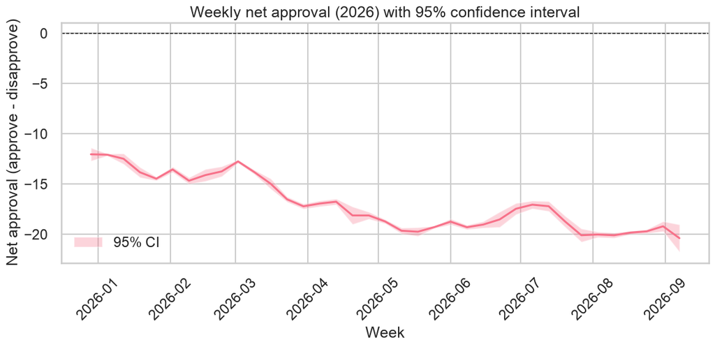

```python
# Choose the presidential term year you want to visualise.
# The approval dataset currently covers 2025-2026, so 2026 is used here.
plot_year = 2026

# Build weekly summaries of net approval (approve - disapprove).
weekly_approval = (
    approval_polllist
    # Convert text dates to datetime objects.
    .assign(modeldate=lambda d: pd.to_datetime(d['modeldate']))
    # Net approval for each daily estimate.
    .assign(net_approval=lambda d: d['approve'] - d['disapprove'])
    # Group each row into the Monday that starts its week.
    .assign(week=lambda d: d['modeldate'].dt.to_period('W').dt.to_timestamp())
    # Keep only the chosen year.
    .query('modeldate.dt.year == @plot_year')
    # Summarise each week.
    .groupby('week', as_index=False)
    .agg(
        mean_net=('net_approval', 'mean'),
        sd_net=('net_approval', 'std'),
        n=('net_approval', 'count')
    )
    # Standard error and 95% confidence interval for each weekly mean.
    .assign(se=lambda d: d['sd_net'] / np.sqrt(d['n']))
    .assign(
        ci_lo=lambda d: d['mean_net'] - stats.t.ppf(0.975, d['n'] - 1) * d['se'],
        ci_hi=lambda d: d['mean_net'] + stats.t.ppf(0.975, d['n'] - 1) * d['se']
    )
)

# Plot the weekly mean and shade the 95% CI.
plt.figure(figsize=(12, 6))
sns.lineplot(data=weekly_approval, x='week', y='mean_net')
plt.fill_between(weekly_approval['week'], weekly_approval['ci_lo'],
                 weekly_approval['ci_hi'], alpha=0.3, label='95% CI')
plt.axhline(0, color='black', linestyle='--', linewidth=1)
plt.title(f'Weekly net approval ({plot_year}) with 95% confidence interval')
plt.xlabel('Week')
plt.ylabel('Net approval (approve - disapprove)')
plt.xticks(rotation=45)
plt.legend()
plt.tight_layout()
plt.show()
```

# Avocados!

The data comes from the Hass Avocado Board and provides weekly sales (total volume in pounds (lbs) and average price in $/lb) in a number of regions around the US. You can find more about the data here https://www.kaggle.com/datasets/timmate/avocado-prices-2020

```python
# ---------------------------------------------------------------------
# Global viz/theme settings (Seaborn-first)
# ---------------------------------------------------------------------
sns.set_theme(style="whitegrid", palette="husl", context="talk")

# ---------------------------------------------------------------------
# Data: Hass avocado sales and prices (Kaggle)
# https://www.kaggle.com/datasets/timmate/avocado-prices-2020
# Notes:
# - 'units' = pounds in the HAB data
# - PLU codes:
#   4046: small/medium Hass (~3-5 oz)
#   4225: large Hass (~8-10 oz)
#   4770: extra large Hass (~10-15 oz)
# ---------------------------------------------------------------------
avocado = (
    pd.read_csv("https://raw.githubusercontent.com/kostis-christodoulou/am01-code-sep2026/main/data/avocado.csv", parse_dates=["date"])
      # drop the national aggregate so every analysis stays at the region level
      .query('region != "TotalUS"')
      .assign(
          # Make some columns categorical for efficiency and clearer semantics
          type=lambda d: d["type"].astype("category"),
          region=lambda d: d["region"].astype("category")
      )
)

avocado['date'] = pd.to_datetime(avocado['date'], dayfirst=True)
```

Please use your data manipulation and visualization skills to answer the following questions:

```
        date  total_volume
0 2015-01-04   52737149.32
1 2015-01-11   48822735.61
2 2015-01-18   48632205.23
3 2015-01-25   47439601.37
4 2015-02-01   74056876.77
```

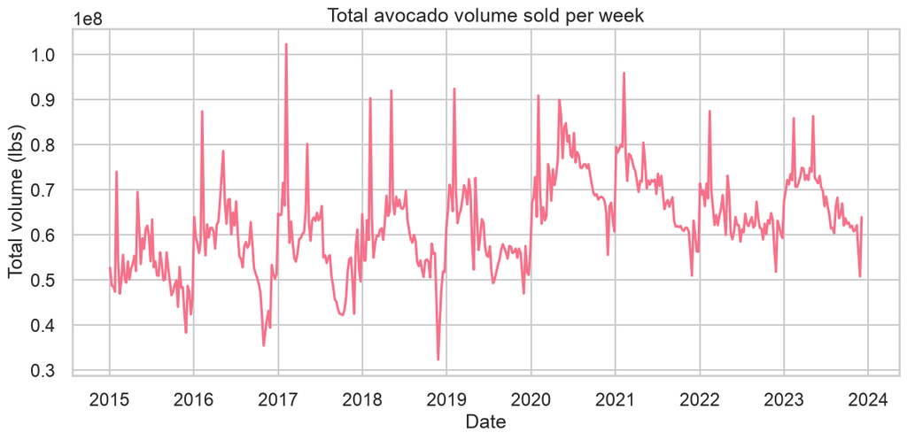

```python
# Total volume sold across all regions and types for each week.
weekly_volume = (
    avocado
    .groupby('date', as_index=False)
    .agg(total_volume=('total_volume', 'sum'))
)

# Show the first few rows.
print(weekly_volume.head())

# Plot weekly total sales over time.
plt.figure(figsize=(12, 6))
sns.lineplot(data=weekly_volume, x='date', y='total_volume')
plt.title('Total avocado volume sold per week')
plt.xlabel('Date')
plt.ylabel('Total volume (lbs)')
plt.tight_layout()
plt.show()
```

Task 2: Total volume by date and type (convetnional vs organic)

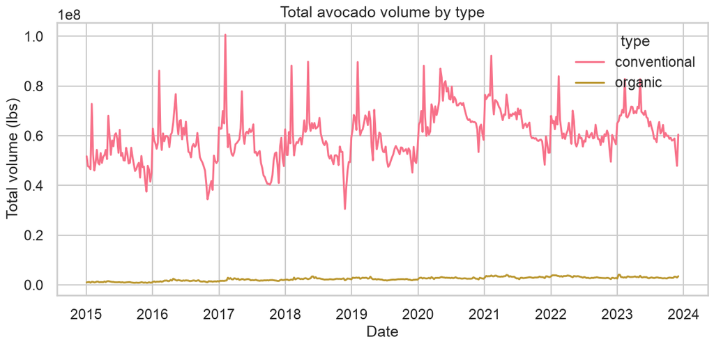

```python
# Total volume by week and type (conventional vs organic).
weekly_by_type = (
    avocado
    .groupby(['date', 'type'], as_index=False)
    .agg(total_volume=('total_volume', 'sum'))
)

# Plot both series on the same axes, using colour to distinguish type.
plt.figure(figsize=(12, 6))
sns.lineplot(data=weekly_by_type, x='date', y='total_volume', hue='type')
plt.title('Total avocado volume by type')
plt.xlabel('Date')
plt.ylabel('Total volume (lbs)')
plt.tight_layout()
plt.show()
```

Task 3: For each date, % split conventional vs organic

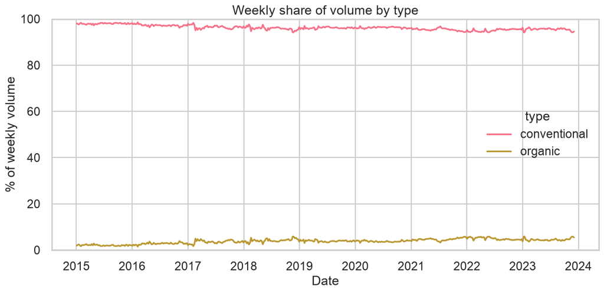

```python
# For each week, compute each type's share of total volume.
share_by_type = (
    avocado
    .groupby(['date', 'type'], as_index=False)
    .agg(total_volume=('total_volume', 'sum'))
    # weekly total across both types
    .assign(weekly_total=lambda d: d.groupby('date')['total_volume'].transform('sum'))
    # convert to percentage
    .assign(pct=lambda d: d['total_volume'] / d['weekly_total'] * 100)
)

# Plot the share of conventional vs organic over time.
plt.figure(figsize=(12, 6))
sns.lineplot(data=share_by_type, x='date', y='pct', hue='type')
plt.title('Weekly share of volume by type')
plt.xlabel('Date')
plt.ylabel('% of weekly volume')
plt.ylim(0, 100)
plt.tight_layout()
plt.show()
```

Task 4: Histogram of prices — conventional vs organic (Seaborn) Two ways: overlaid (hue) and faceted

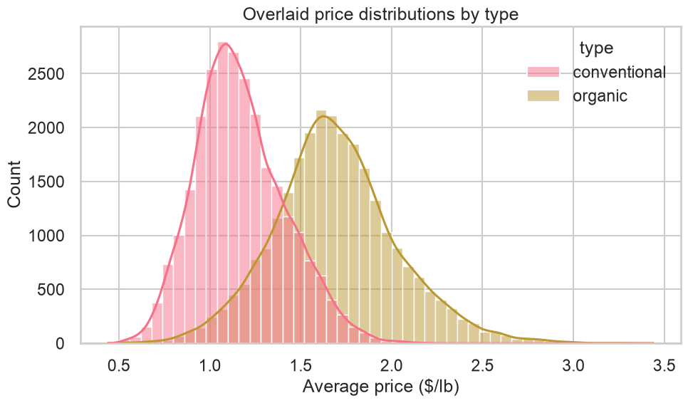

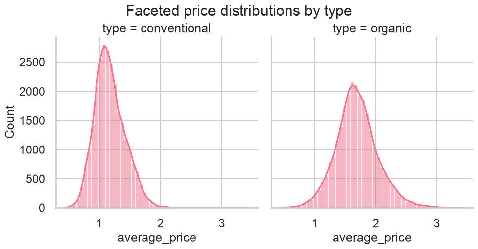

```python
# Two ways to compare price distributions by type.

# 1) Overlaid histogram with a kernel-density estimate.
plt.figure(figsize=(10, 6))
sns.histplot(data=avocado, x='average_price', hue='type',
             bins=50, kde=True, alpha=0.5)
plt.title('Overlaid price distributions by type')
plt.xlabel('Average price ($/lb)')
plt.tight_layout()
plt.show()

# 2) Faceted histograms, one panel per type.
sns.displot(data=avocado, x='average_price', col='type',
            bins=50, kde=True, height=5, aspect=1)
plt.suptitle('Faceted price distributions by type', y=1.02)
plt.show()
```

Task 5: Table — total volume and mean price by date

```python
# Summary table: total volume and mean price for each week.
daily_summary = (
    avocado
    .groupby('date', as_index=False)
    .agg(
        total_volume=('total_volume', 'sum'),
        mean_price=('average_price', 'mean')
    )
)

print(daily_summary.head(10))
```

```
        date  total_volume  mean_price
0 2015-01-04   52737149.32    1.303113
1 2015-01-11   48822735.61    1.373585
2 2015-01-18   48632205.23    1.394245
3 2015-01-25   47439601.37    1.399245
4 2015-02-01   74056876.77    1.249340
5 2015-02-08   53802898.88    1.312264
6 2015-02-15   47008465.10    1.389151
7 2015-02-22   50265918.30    1.364528
8 2015-03-01   55626344.31    1.313396
9 2015-03-08   50403061.78    1.362075
```

Task 6: Scatter (price vs volume) by type, with trend lines Use seaborn lmplot (facetted) to show linear fit

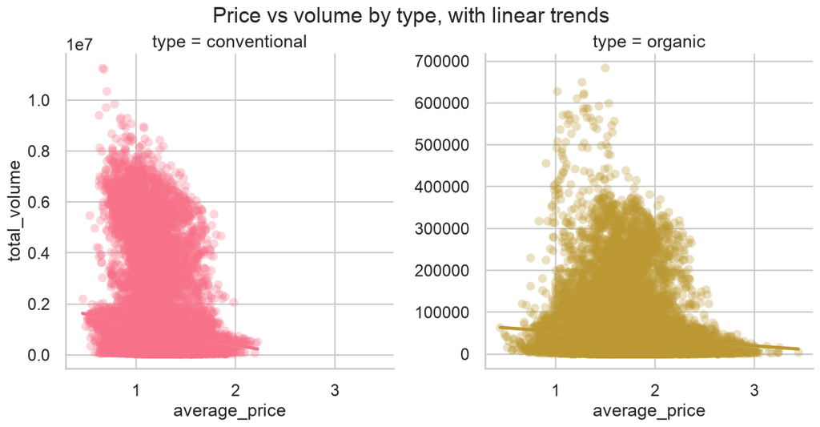

```python
# Scatter of price vs volume, separate panels and colours by type,
# with linear regression trend lines.
sns.lmplot(data=avocado, x='average_price', y='total_volume',
           hue='type', col='type', height=6, aspect=1,
           scatter_kws={'alpha': 0.3},
           sharey=False  # <- separate y axes per panel
)
plt.suptitle('Price vs volume by type, with linear trends', y=1.02)
plt.show()
```

Task 7: Mean price by geography and type (table)

```python
# Mean price for each geography-type combination, reshaped to a wide table.
mean_price_table = (
    avocado
    .groupby(['region', 'type'], as_index=False)
    .agg(mean_price=('average_price', 'mean'))
    # wide format: one column per type
    .pivot(index='region', columns='type', values='mean_price')
    .reset_index()
)

print(mean_price_table.head(10))
```

```
type                region  conventional   organic
0                   Albany      1.231408  1.771236
1                  Atlanta      1.067537  1.684377
2      BaltimoreWashington      1.358278  1.707750
3     BirminghamMontgomery      1.056598  1.419889
4                    Boise      1.192552  1.883526
5                   Boston      1.386630  1.849712
6         BuffaloRochester      1.274506  1.671223
7               California      1.229127  1.793486
8                Charlotte      1.262354  1.754091
9                  Chicago      1.349173  1.746279
```

Task 8: Time series of mean prices by type (national mean across geographies)

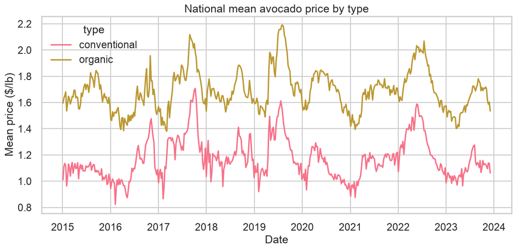

```python
# National mean price by type over time.
# We exclude the aggregate "TotalUS" region so we average across states/regions.
national_price = (
    avocado
    .groupby(['date', 'type'], as_index=False)
    .agg(mean_price=('average_price', 'mean'))
)

plt.figure(figsize=(12, 6))
sns.lineplot(data=national_price, x='date', y='mean_price', hue='type')
plt.title('National mean avocado price by type')
plt.xlabel('Date')
plt.ylabel('Mean price ($/lb)')
plt.tight_layout()
plt.show()
```

Task 9: Total volume by geography and type (table) + time series by type

```
type                region  conventional       organic
0                   Albany  5.158951e+07  1.267557e+06
1                  Atlanta  2.970266e+08  1.069397e+07
2      BaltimoreWashington  3.916638e+08  1.973696e+07
3     BirminghamMontgomery  9.492250e+07  3.257581e+06
4                    Boise  4.613652e+07  1.834603e+06
5                   Boston  2.719283e+08  1.055077e+07
6         BuffaloRochester  7.387090e+07  4.533022e+06
7               California  2.721549e+09  1.093928e+08
8                Charlotte  1.275721e+08  6.415087e+06
9                  Chicago  3.743914e+08  1.820733e+07
```

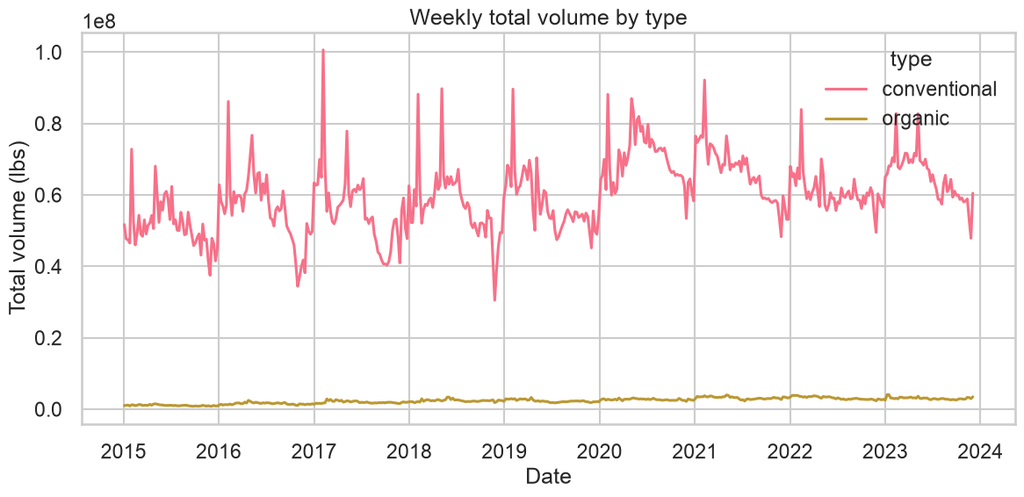

```python
# Table: total volume by geography and type.
geo_volume_table = (
    avocado
    .groupby(['region', 'type'], as_index=False)
    .agg(total_volume=('total_volume', 'sum'))
    .pivot(index='region', columns='type', values='total_volume')
    .reset_index()
)

print(geo_volume_table.head(10))

# Time series: total national volume by type each week.
weekly_volume_type = (
    avocado
    .groupby(['date', 'type'], as_index=False)
    .agg(total_volume=('total_volume', 'sum'))
)

plt.figure(figsize=(12, 6))
sns.lineplot(data=weekly_volume_type, x='date', y='total_volume', hue='type')
plt.title('Weekly total volume by type')
plt.xlabel('Date')
plt.ylabel('Total volume (lbs)')
plt.tight_layout()
plt.show()
```

Task 10: Which geography generates most sales? Exclude "Total U.S.", compute percent and cumulative percent; show top 10, table and barplot

```
          region  total_volume        pct    cum_pct
56          West  3.102195e+09  10.666572  10.666572
7     California  2.830942e+09   9.733897  20.400470
49  SouthCentral  2.707226e+09   9.308511  29.708981
31     Northeast  2.291012e+09   7.877404  37.586385
50     Southeast  2.132529e+09   7.332478  44.918863
16    GreatLakes  1.751851e+09   6.023555  50.942418
27      Midsouth  1.651154e+09   5.677320  56.619738
23    LosAngeles  1.370956e+09   4.713887  61.333626
38        Plains  8.912865e+08   3.064595  64.398220
30       NewYork  7.910913e+08   2.720084  67.118305
```

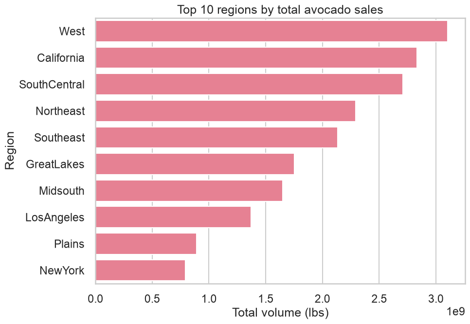

```python
# Rank geographies by total sales.
region_sales = (
    avocado
    .groupby('region', as_index=False)
    .agg(total_volume=('total_volume', 'sum'))
    # sort from largest to smallest
    .sort_values('total_volume', ascending=False)
    # percentage of total and running cumulative percentage
    .assign(
        pct=lambda d: d['total_volume'] / d['total_volume'].sum() * 100,
        cum_pct=lambda d: d['pct'].cumsum()
    )
)

# Top 10 table.
top10 = region_sales.head(10)
print(top10)

# Barplot of the top 10 regions.
plt.figure(figsize=(10, 7))
sns.barplot(data=top10, y='region', x='total_volume', order=top10['region'])
plt.title('Top 10 regions by total avocado sales')
plt.xlabel('Total volume (lbs)')
plt.ylabel('Region')
plt.tight_layout()
plt.show()
```

Task 11: Price elasticity of demand (approx): Δvolume vs Δprice (ratios), calculation and scatterplot (sns.lmplot)

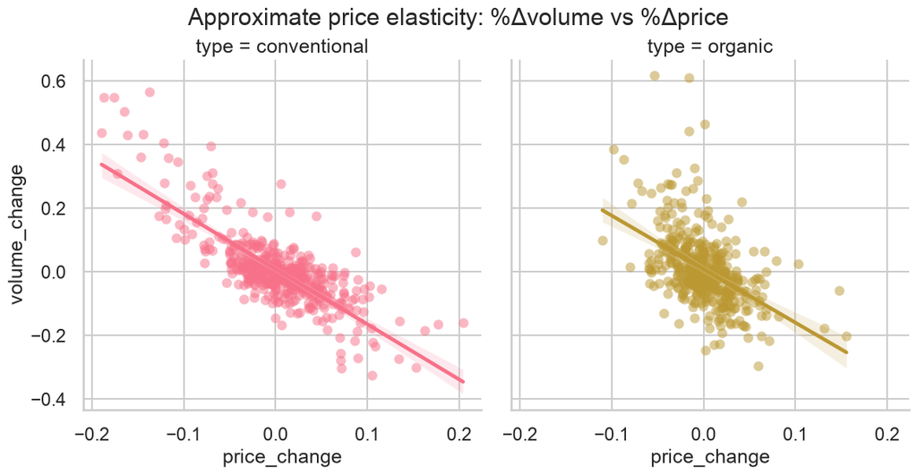

```python
# Approximate price elasticity: percentage change in volume vs price.
elasticity = (
    avocado
    # national weekly totals by type
    .groupby(['date', 'type'], as_index=False)
    .agg(total_volume=('total_volume', 'sum'), mean_price=('average_price', 'mean'))
    # ensure rows are in chronological order within each type
    .sort_values(['type', 'date'])
    # percentage change from one week to the next, computed separately by type
    .assign(
        price_change=lambda d: d.groupby('type')['mean_price'].pct_change(),
        volume_change=lambda d: d.groupby('type')['total_volume'].pct_change()
    )
    # drop the first observation of each type (no previous week to compare to)
    .dropna(subset=['price_change', 'volume_change'])
)

# Scatterplot with linear fit, faceted by type.
sns.lmplot(data=elasticity, x='price_change', y='volume_change',
           hue='type', col='type', height=6, aspect=1,
           scatter_kws={'alpha': 0.5})
plt.suptitle('Approximate price elasticity: %Δvolume vs %Δprice', y=1.02)
plt.show()
```

Task 12: Cumulative change of price by type (normalize to first date = 1)

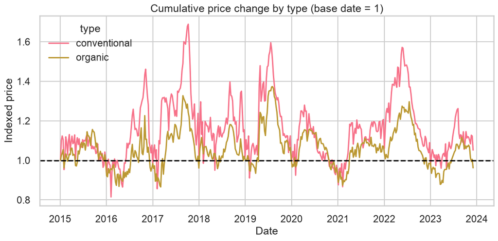

```python
# Cumulative price change by type, indexed to 1 at the first date.
cumulative_price = (
    avocado
    .groupby(['date', 'type'], as_index=False)
    .agg(mean_price=('average_price', 'mean'))
    .sort_values(['type', 'date'])
    # first price for each type
    .assign(first_price=lambda d: d.groupby('type')['mean_price'].transform('first'))
    # index relative to the first observation
    .assign(indexed=lambda d: d['mean_price'] / d['first_price'])
)

plt.figure(figsize=(12, 6))
sns.lineplot(data=cumulative_price, x='date', y='indexed', hue='type')
plt.title('Cumulative price change by type (base date = 1)')
plt.xlabel('Date')
plt.ylabel('Indexed price')
plt.axhline(1, color='black', linestyle='--')
plt.tight_layout()
plt.show()
```

# Challenge 1: Risk-Return Tradeoff Plot by year

Last week we downloaded prices of stocks from yahoo finance using `yfinance` and calcualted the risk-return tradeoff for each stock. However, that graph was for the toal time period. What if we wanted to produce a risk-return tradeoff for each of the past five years?

The code below will download the adjusted closing price for a few stocks from Yahoo finance. Your task is to manipulate the data and to produce a graph that look like the one below. There is no need to reproduce evry single aesthetic detail of the plot-- the key is to get your data manipulation right!

The final graph should look like this:

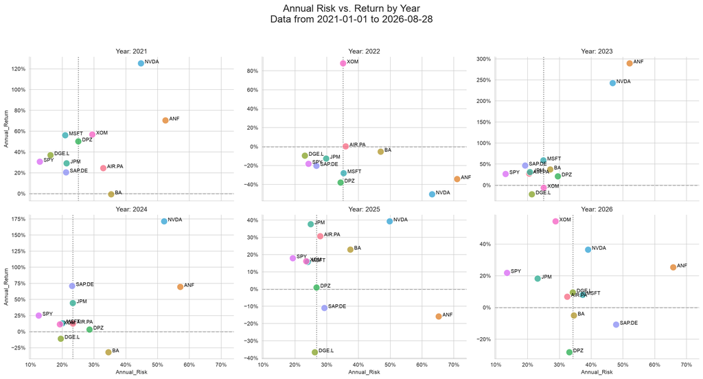

```python
# =============================================================================
# 1. SETUP AND DATA DOWNLOAD
# =============================================================================
tickers = ['SPY', 'NVDA', 'AIR.PA', 'MSFT', 'BA', 'JPM', 'XOM','DGE.L','ANF','DPZ', 'SAP.DE']

# Dynamically set the date range for the last 5 full years
end_date = date.today()
start_date = date(end_date.year - 5, 1, 1)

print(f"Downloading historical stock data from {start_date} to {end_date}...")
adj_close_df = yf.download(tickers,
                           start=start_date,
                           end=end_date,
                           auto_adjust=False)['Adj Close']

print("\n--- Downloaded Data (First 5 Rows) ---")
print(adj_close_df.head(5))
```

```
[*********************100%***********************]  11 of 11 completed
```

```
Downloading historical stock data from 2021-01-01 to 2026-09-08...

--- Downloaded Data (First 5 Rows) ---
Ticker         AIR.PA        ANF          BA        DGE.L         DPZ  \
Date
2021-01-04  82.468239  20.490000  202.720001  2943.570068  352.243958
2021-01-05  82.413193  21.370001  211.630005  2941.073730  353.951843
2021-01-06  82.725113  22.240000  211.029999  2942.072510  357.228363
2021-01-07  82.220535  21.209999  212.710007  2984.508545  355.669098
2021-01-08  82.660904  21.530001  209.899994  3033.434570  360.903900

Ticker             JPM        MSFT       NVDA     SAP.DE         SPY  \
Date
2021-01-04  109.000526  207.565369  13.060795  95.391235  342.436981
2021-01-05  109.593636  207.765594  13.350875  95.137627  344.795441
2021-01-06  114.739700  202.378357  12.563803  95.536156  346.856812
2021-01-07  118.507660  208.137482  13.290369  94.666649  352.010193
2021-01-08  118.638489  209.405624  13.223392  96.170166  354.015839

Ticker            XOM
Date
2021-01-04  33.251335
2021-01-05  34.853794
2021-01-06  35.743183
2021-01-07  36.023617
2021-01-08  36.424221
```

```
--- Annual Risk-Return Metrics (Tidy Format) ---
   Year  Ticker  Annual_Return  Annual_Risk
0  2021  AIR.PA       0.244558     0.328997
1  2021     ANF       0.703450     0.524816
2  2021      BA      -0.006933     0.353863
3  2021   DGE.L       0.369367     0.162974
4  2021     DPZ       0.501845     0.250502
5  2021     JPM       0.290944     0.213546
6  2021    MSFT       0.560654     0.209321
7  2021    NVDA       1.252005     0.447701
8  2021  SAP.DE       0.203952     0.211891
9  2021     SPY       0.306440     0.129356
Generating plot...
```

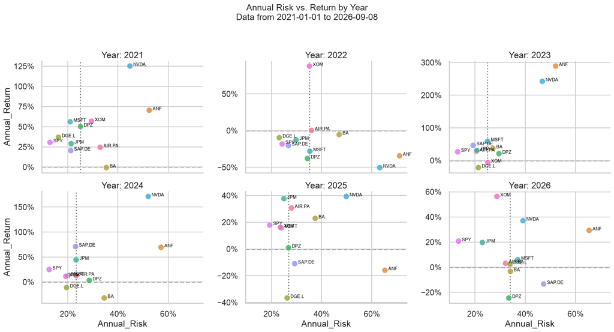

```python
# =============================================================================
# 3. TURN THE DATAFRAME IN LONG FORMAT
# =============================================================================

long_df = (adj_close_df
           .reset_index()
           .melt(id_vars='Date', var_name='Ticker', value_name='Adj_Close')
           .dropna()
           .sort_values(['Ticker', 'Date'])
           .reset_index(drop=True))

long_df['Year'] = long_df['Date'].dt.year

# Simple daily return: (today / yesterday) - 1
long_df['Simple_Return'] = long_df.groupby('Ticker')['Adj_Close'].pct_change()
# Log daily return: ln(today / yesterday)
long_df['Log_Return'] = (long_df.groupby('Ticker')['Adj_Close']
                         .transform(lambda p: np.log(p / p.shift(1))))

long_df.head()

# =============================================================================
# 3. ANNUAL RISK-RETURN ANALYSIS IN LONG FORMAT
# =============================================================================
TRADING_DAYS = 252


yearly = (long_df.groupby(['Year', 'Ticker'])
          .agg(mean_simple=('Simple_Return', 'mean'),
               mean_log=('Log_Return', 'mean'),
               std_log=('Log_Return', 'std'),        # risk from LOG returns
               first_px=('Adj_Close', 'first'),
               last_px=('Adj_Close', 'last'),
               Days=('Simple_Return', 'count'))
          .reset_index())

# M1: the real point-to-point return for that year (first vs last price).
yearly['M1_point_to_point'] = yearly['last_px'] / yearly['first_px'] - 1
# M2 / M3 / M4: the shortcuts, but averaged WITHIN the year only.
yearly['M2_yearly'] = yearly['mean_simple'] * TRADING_DAYS
yearly['M3_yearly'] = yearly['mean_log'] * TRADING_DAYS
yearly['M4_yearly'] = np.exp(yearly['M3_yearly']) - 1
# Annualised risk for that single year, from LOG returns.
yearly['Risk_yearly'] = yearly['std_log'] * np.sqrt(TRADING_DAYS)

yearly.head()



# Annualize metrics

annual_metrics = yearly.assign(
    Annual_Return=np.exp(yearly['mean_log'] * TRADING_DAYS) - 1,
    Annual_Risk=yearly['std_log'] * np.sqrt(TRADING_DAYS),
)

print("--- Annual Risk-Return Metrics (Tidy Format) ---")
print(annual_metrics[['Year', 'Ticker', 'Annual_Return', 'Annual_Risk']]
      .head(10).to_string())



# =============================================================================
# 4. PLOTTING WITH SEABORN AND DIRECT LABELS (MODIFIED)
# ==========================================
# sns.set_style("whitegrid")
print("Generating plot...")
g = sns.relplot(
    data=annual_metrics,
    x='Annual_Risk',
    y='Annual_Return',
    hue='Ticker',
    col='Year',
    col_wrap=3,
    s=150,
    alpha=0.8,
    height=5,
    aspect=1.2,
    kind='scatter',
    legend=False,
    facet_kws={'sharey': False}   # let each year's panel auto-scale its own y-axis
)

for year, ax in g.axes_dict.items():
    ax.set_title(f"Year: {year}")
    year_data = annual_metrics[annual_metrics['Year'] == year]

    # Direct text label next to each point
    for idx, row in year_data.iterrows():
        ax.annotate(
            text=row['Ticker'],
            xy=(row['Annual_Risk'], row['Annual_Return']),
            color='black',
            size=9,
            weight='normal',
            xytext=(7, 0),
            textcoords='offset points'
        )

    # Percent-format the axes and add reference lines
    ax.xaxis.set_major_formatter(mticker.PercentFormatter(1.0, decimals=0))
    ax.yaxis.set_major_formatter(mticker.PercentFormatter(1.0, decimals=0))
    ax.axhline(0, ls='--', color='gray', zorder=0)

    if not year_data.empty:
        median_risk = year_data['Annual_Risk'].median()
        ax.axvline(median_risk, ls=':', color='gray', zorder=0, label='Median Risk')

title_str = (f"Annual Risk vs. Return by Year\n"
             f"Data from {start_date.strftime('%Y-%m-%d')} to {end_date.strftime('%Y-%m-%d')}")
g.fig.suptitle(title_str, fontsize=18)
g.fig.tight_layout(rect=[0, 0.02, 1, 0.95])

plt.show()
```

```
Generating plot...
```

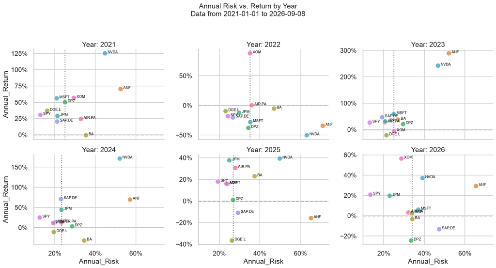

```python
print("Generating plot...")

g = sns.relplot(
    data=annual_metrics,
    x='Annual_Risk',
    y='Annual_Return',
    hue='Ticker',
    col='Year',
    col_wrap=3,
    s=150,
    alpha=0.8,
    height=5,
    aspect=1.2,
    kind='scatter',
    legend=False,
    facet_kws={'sharey': False}   # let each year's panel auto-scale its own y-axis
)

for year, ax in g.axes_dict.items():
    ax.set_title(f"Year: {year}")
    year_data = annual_metrics[annual_metrics['Year'] == year]

    # Direct text label next to each point
    for idx, row in year_data.iterrows():
        ax.annotate(
            text=row['Ticker'],
            xy=(row['Annual_Risk'], row['Annual_Return']),
            color='black',
            size=9,
            weight='normal',
            xytext=(7, 0),
            textcoords='offset points'
        )

    # Percent-format the axes and add reference lines
    ax.xaxis.set_major_formatter(mticker.PercentFormatter(1.0, decimals=0))
    ax.yaxis.set_major_formatter(mticker.PercentFormatter(1.0, decimals=0))
    ax.axhline(0, ls='--', color='gray', zorder=0)

    if not year_data.empty:
        median_risk = year_data['Annual_Risk'].median()
        ax.axvline(median_risk, ls=':', color='gray', zorder=0, label='Median Risk')

title_str = (f"Annual Risk vs. Return by Year\n"
             f"Data from {start_date.strftime('%Y-%m-%d')} to {end_date.strftime('%Y-%m-%d')}")
g.fig.suptitle(title_str, fontsize=18)
g.fig.tight_layout(rect=[0, 0.02, 1, 0.95])
plt.show()
```

# Challenge 2: Yield Curve Challenge

We have downloaded data on the US yield curve from 1960 to last month

Yield curve inversion occurs when short-term interest rates (3 months) exceed long-term rates (10 years), creating a downward-sloping yield curve instead of the normal upward slope.

This unusual pattern has historically preceded most U.S. recessions, making it a closely watched economic indicator.

The code below will download the data on the yield curve from FRED-- eg, the 10 year bond is at https://fred.stlouisfed.org/series/DGS10. I got dates for US recessions from https://en.wikipedia.org/wiki/List_of_recessions_in_the_United_States and have added them in a `recessions` dataframe for you.

Your task is to manipulate the data and to produce a graph that look like the one below. There is no need to reproduce every single aesthetic detail of the plot-- the key is to get your data manipulation right. Besides your code, please explain how you approached this issue

The final graph should look like this:

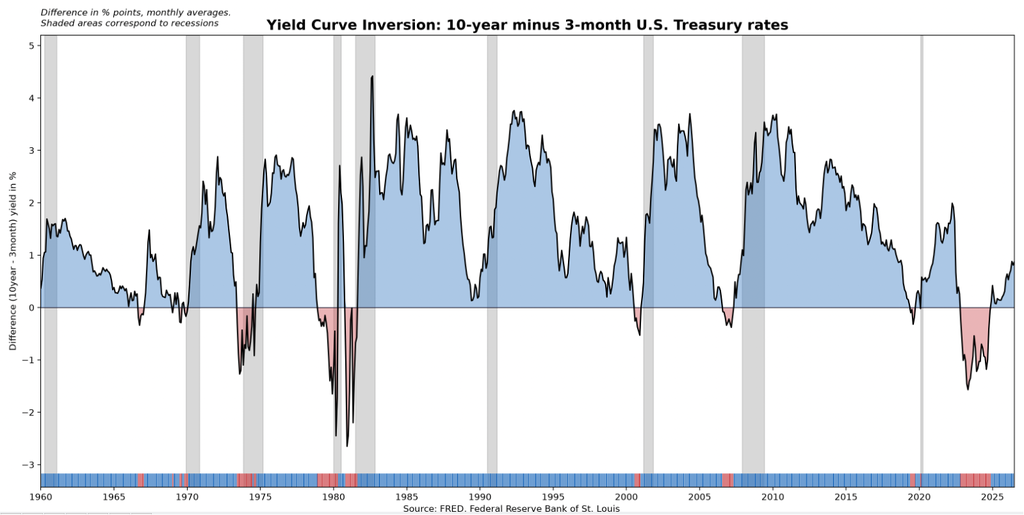

```python
# --- Data Preparation ---

# Get a list of FRED codes for US rates and US yield curve; choose monthly frequency
tickers = [
    'TB3MS',  # 3-month Treasury bill (or T-bill)
    'TB6MS',  # 6-month
    'GS1',    # 1-year
    'GS2',    # 2-year, etc....
    'GS3',
    'GS5',
    'GS7',
    'GS10',
    'GS20',
    'GS30'    #.... all the way to the 30-year rate
]

# Turn FRED codes to human readable variables
myvars = [
    '3-Month Treasury Bill',
    '6-Month Treasury Bill',
    '1-Year Treasury Rate',
    '2-Year Treasury Rate',
    '3-Year Treasury Rate',
    '5-Year Treasury Rate',
    '7-Year Treasury Rate',
    '10-Year Treasury Rate',
    '20-Year Treasury Rate',
    '30-Year Treasury Rate'
]

maturity = ['3m', '6m', '1y', '2y', '3y', '5y', '7y', '10y', '20y', '30y']

# Create a lookup dataframe
mylookup = pd.DataFrame({
    'symbol': tickers,
    'var': myvars,
    'maturity': maturity
})

# Display the lookup table
print("--- Lookup Table ---")
print(mylookup)
print("\n")

# Use a function for a cleaner pipe
def prepare_yield_curve_data(df, lookup):
    """
    This function takes the raw data from FRED and the lookup table,
    and returns a clean, long-format DataFrame.
    """
    return (
        df
        .reset_index() # Turn the 'DATE' index into a column
        .rename(columns={'DATE': 'date'})
        # Melt the dataframe from wide to long format
        .melt(id_vars='date', var_name='symbol', value_name='value')
        # Merge with the lookup table to get human-readable names
        .merge(lookup, on='symbol')
        # Convert 'maturity' and 'var' to ordered categorical types
        # This is similar to R's factor() with specified levels
        .assign(
            maturity=lambda x: pd.Categorical(x['maturity'], categories=maturity, ordered=True),
            duration=lambda x: pd.Categorical(x['var'], categories=myvars, ordered=True)
        )
    )

# Fetch the data from FRED and process it using a chain of commands
yield_curve = (
    web.DataReader(tickers, 'fred', start='1960-01-01')
    .pipe(prepare_yield_curve_data, mylookup)
)

print("--- Yield Curve Data (First 5 Rows) ---")
print(yield_curve.head())
print("\n")


# Set up recession indicators
recessions = pd.DataFrame({
    'from': ["1948-11-01", "1953-07-01", "1957-08-01", "1960-04-01", "1969-12-01",
             "1973-11-01", "1980-01-01", "1981-07-01", "1990-07-01", "2001-03-01",
             "2007-12-01", "2020-02-01"],
    'to': ["1949-10-01", "1954-05-01", "1958-04-01", "1961-02-01", "1970-11-01",
           "1975-03-01", "1980-07-01", "1982-11-01", "1991-03-01", "2001-11-01",
           "2009-06-01", "2020-04-01"]
}).pipe(lambda df: df.assign(
    From=pd.to_datetime(df['from']),
    To=pd.to_datetime(df['to'])
))
```

```
--- Lookup Table ---
  symbol                    var maturity
0  TB3MS  3-Month Treasury Bill       3m
1  TB6MS  6-Month Treasury Bill       6m
2    GS1   1-Year Treasury Rate       1y
3    GS2   2-Year Treasury Rate       2y
4    GS3   3-Year Treasury Rate       3y
5    GS5   5-Year Treasury Rate       5y
6    GS7   7-Year Treasury Rate       7y
7   GS10  10-Year Treasury Rate      10y
8   GS20  20-Year Treasury Rate      20y
9   GS30  30-Year Treasury Rate      30y


--- Yield Curve Data (First 5 Rows) ---
        date symbol  value                    var maturity  \
0 1960-01-01  TB3MS   4.35  3-Month Treasury Bill       3m
1 1960-02-01  TB3MS   3.96  3-Month Treasury Bill       3m
2 1960-03-01  TB3MS   3.31  3-Month Treasury Bill       3m
3 1960-04-01  TB3MS   3.23  3-Month Treasury Bill       3m
4 1960-05-01  TB3MS   3.29  3-Month Treasury Bill       3m

                duration
0  3-Month Treasury Bill
1  3-Month Treasury Bill
2  3-Month Treasury Bill
3  3-Month Treasury Bill
4  3-Month Treasury Bill
```

```
--- Wide Yield Curve Data with Inversion (First 5 Rows) ---
symbol       date   GS1  GS10  GS2  GS20   GS3  GS30   GS5  GS7  TB3MS  TB6MS  \
0      1960-01-01  5.03  4.72  NaN  4.42  4.99   NaN  4.92  NaN   4.35   4.74
1      1960-02-01  4.66  4.49  NaN  4.28  4.73   NaN  4.69  NaN   3.96   4.30
2      1960-03-01  4.02  4.25  NaN  4.14  4.29   NaN  4.31  NaN   3.31   3.61
3      1960-04-01  4.04  4.28  NaN  4.23  4.27   NaN  4.29  NaN   3.23   3.55
4      1960-05-01  4.21  4.35  NaN  4.20  4.46   NaN  4.49  NaN   3.29   3.58

symbol  spread_10y_3m    up  down
0                0.37  0.37   0.0
1                0.53  0.53   0.0
2                0.94  0.94   0.0
3                1.05  1.05   0.0
4                1.06  1.06   0.0
```

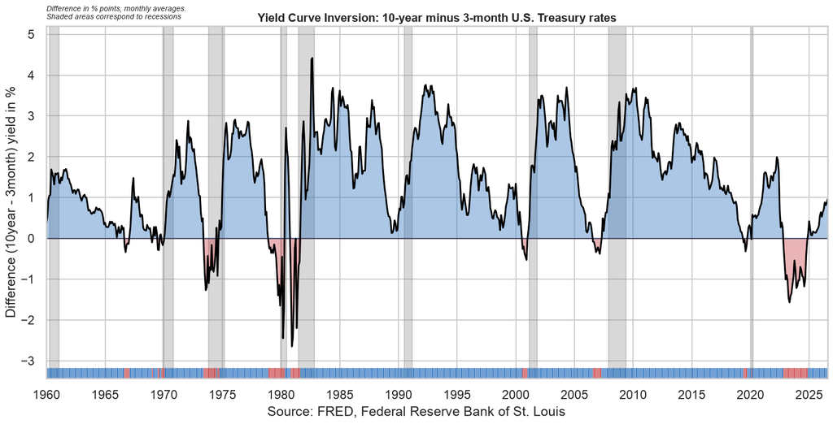

```python
# Use a function to pivot and calculate inversion metrics
def calculate_inversion(df):
    """Pivots data to wide format and calculates yield curve spreads."""
    return (
        df
        .pivot_table(index='date', columns='symbol', values='value')
        .assign(
            spread_10y_3m = lambda x: x['GS10'] - x['TB3MS'],
            up=lambda x: np.where(x['spread_10y_3m'] >= 0, x['spread_10y_3m'], 0),
            down=lambda x: np.where(x['spread_10y_3m'] < 0, x['spread_10y_3m'], 0)
        )
        .reset_index()
    )

yield_curve_wide = yield_curve.pipe(calculate_inversion)

print("--- Wide Yield Curve Data with Inversion (First 5 Rows) ---")
print(yield_curve_wide.head())
print("\n")

# Set up recession indicators
recessions = pd.DataFrame({
    'from': ["1948-11-01", "1953-07-01", "1957-08-01", "1960-04-01", "1969-12-01",
             "1973-11-01", "1980-01-01", "1981-07-01", "1990-07-01", "2001-03-01",
             "2007-12-01", "2020-02-01"],
    'to': ["1949-10-01", "1954-05-01", "1958-04-01", "1961-02-01", "1970-11-01",
           "1975-03-01", "1980-07-01", "1982-11-01", "1991-03-01", "2001-11-01",
           "2009-06-01", "2020-04-01"]
}).pipe(lambda df: df.assign(
    From=pd.to_datetime(df['from']),
    To=pd.to_datetime(df['to'])
))


# Plot inversion + recessions
start_date = '1960-01-01'
filtered_recessions = recessions.query(f"From > '{start_date}'")
filtered_yield_curve = yield_curve_wide.dropna(subset=['TB3MS', 'GS10'])

# Create the plot
fig, ax = plt.subplots(figsize=(16, 8))

# Place a tick every 5 years
ax.xaxis.set_major_locator(mdates.YearLocator(5))
ax.xaxis.set_major_formatter(mdates.DateFormatter('%Y'))

# Add recession shading
for _, row in filtered_recessions.iterrows():
    ax.axvspan(row['From'], row['To'], color='gray', alpha=0.3)

# Plot the yield curve spread
ax.plot(filtered_yield_curve['date'], filtered_yield_curve['spread_10y_3m'], color='black')

# Add a horizontal line at 0
ax.axhline(0, color='black', lw=0.5)

# Add ribbons for up/down
ax.fill_between(filtered_yield_curve['date'], 0, filtered_yield_curve['down'],
                color="#CB454A", alpha=0.4)
ax.fill_between(filtered_yield_curve['date'], 0, filtered_yield_curve['up'],
                color="#2E74C0", alpha=0.4)

# Add geom_rug() equivalent
sns.rugplot(data=filtered_yield_curve, x='date',
            hue=np.where(filtered_yield_curve['spread_10y_3m'] >= 0, ">=0", "<0"),
            palette={"<0": "#CB454A", ">=0": "#2E74C0"}, ax=ax, height=0.03, legend=False)

# Formatting
ax.set_xlabel(None)
ax.set_ylabel('Difference (10year - 3month) yield in %')
ax.set_title('Yield Curve Inversion: 10-year minus 3-month U.S. Treasury rates',
             fontweight='bold', fontsize=16)
ax.text(0, 1.02, 'Difference in % points, monthly averages.\nShaded areas correspond to recessions',
        transform=ax.transAxes, fontsize=10, style='italic')
fig.text(0.5, 0, "Source: FRED, Federal Reserve Bank of St. Louis", ha='center')


import matplotlib.dates as mdates
ax.xaxis.set_major_locator(mdates.YearLocator(5))
ax.xaxis.set_major_formatter(mdates.DateFormatter('%Y'))

# Remove left/right padding on the x-axis
ax.margins(x=0)

# Or explicitly:
# ax.set_xlim(left=pd.Timestamp('1960-01-01'))

# If you also want to remove the small gap at the end (right side):
ax.set_xlim(pd.Timestamp('1960-01-01'), filtered_yield_curve['date'].max())

plt.tight_layout()
plt.show()
```